# Project

Atharva Jadhav | Harshali Gaikwad | Sriujan Harihar

2025-04-12

```r
library(tidyverse)
library(tseries)
library(forecast)
library(Metrics)
library(ggplot2)
library(tibble)
library(scales)
```

**Part I: Data Loading**

```r
data = read.csv("pollution_us_2000_2016.csv")
```

```r
data_df = data.frame(data)
```

**Part II: Data Cleaning**

```r
na_counts <- colSums(is.na(data_df)) # Find the number of NA values in each column
print(na_counts)
```

```
##                 X        State.Code       County.Code          Site.Num
##                 0                 0                 0                 0
##           Address             State            County              City
##                 0                 0                 0                 0
##        Date.Local         NO2.Units          NO2.Mean NO2.1st.Max.Value
##                 0                 0                 0                 0
##  NO2.1st.Max.Hour           NO2.AQI          O3.Units           O3.Mean
##                 0                 0                 0                 0
##  O3.1st.Max.Value   O3.1st.Max.Hour            O3.AQI         SO2.Units
##                 0                 0                 0                 0
##          SO2.Mean SO2.1st.Max.Value  SO2.1st.Max.Hour           SO2.AQI
##                 0                 0                 0            872907
##          CO.Units           CO.Mean  CO.1st.Max.Value   CO.1st.Max.Hour
##                 0                 0                 0                 0
##            CO.AQI
##            873323
```

```r
cleaned_df <- data.frame(lapply(data_df, function(x) {
  if (is.numeric(x)) {
    x[is.na(x)] <- mean(x, na.rm = TRUE)
  }
  return(x)
}))
```

```r
na_counts <- colSums(is.na(cleaned_df))
print(na_counts)
```

```
##                 X        State.Code       County.Code          Site.Num
##                 0                 0                 0                 0
##           Address             State            County              City
##                 0                 0                 0                 0
##        Date.Local         NO2.Units          NO2.Mean NO2.1st.Max.Value
##                 0                 0                 0                 0
##  NO2.1st.Max.Hour           NO2.AQI          O3.Units           O3.Mean
##                 0                 0                 0                 0
##  O3.1st.Max.Value   O3.1st.Max.Hour            O3.AQI         SO2.Units
##                 0                 0                 0                 0
##          SO2.Mean SO2.1st.Max.Value  SO2.1st.Max.Hour           SO2.AQI
##                 0                 0                 0                 0
##          CO.Units           CO.Mean  CO.1st.Max.Value   CO.1st.Max.Hour
##                 0                 0                 0                 0
##            CO.AQI
##                 0
```

**Part III: Time Series ~ County - Cook**

```r
cleaned_df$Date.Local <- as.POSIXct(cleaned_df$Date.Local, format = "%Y-%m-%d")
cleaned_df_cook <- subset(cleaned_df, County == "Cook")

cleaned_df_cook_floored <- cleaned_df_cook %>%
  mutate(YearMonth = floor_date(Date.Local, "month"))
```

```r
monthly_data <- cleaned_df_cook_floored %>%
  group_by(YearMonth) %>%
  summarise(mean_CO = mean(CO.Mean, na.rm = TRUE))
```

**1. Plot the Time Series for Cook**

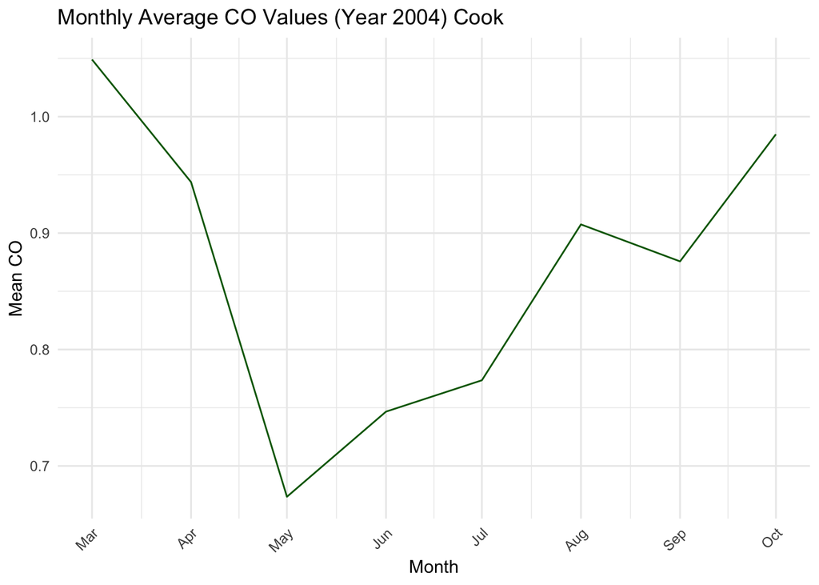

```r
monthly_data$YearMonth <- as.Date(monthly_data$YearMonth)

monthly_data_2004 <- monthly_data %>%
  filter(format(YearMonth, "%Y") == "2004")

ggplot(monthly_data_2004, aes(x = YearMonth, y = mean_CO)) +
  geom_line(color = "darkgreen") +
  labs(title = "Monthly Average CO Values (Year 2004) Cook",
       x = "Month",
       y = "Mean CO") +
  scale_x_date(date_breaks = "1 month", date_labels = "%b") +  # Show each month name
  theme_minimal() +
  theme(axis.text.x = element_text(angle = 45, hjust = 1))
```

**2. Plot the Monthly Mean Time Series for Cook**

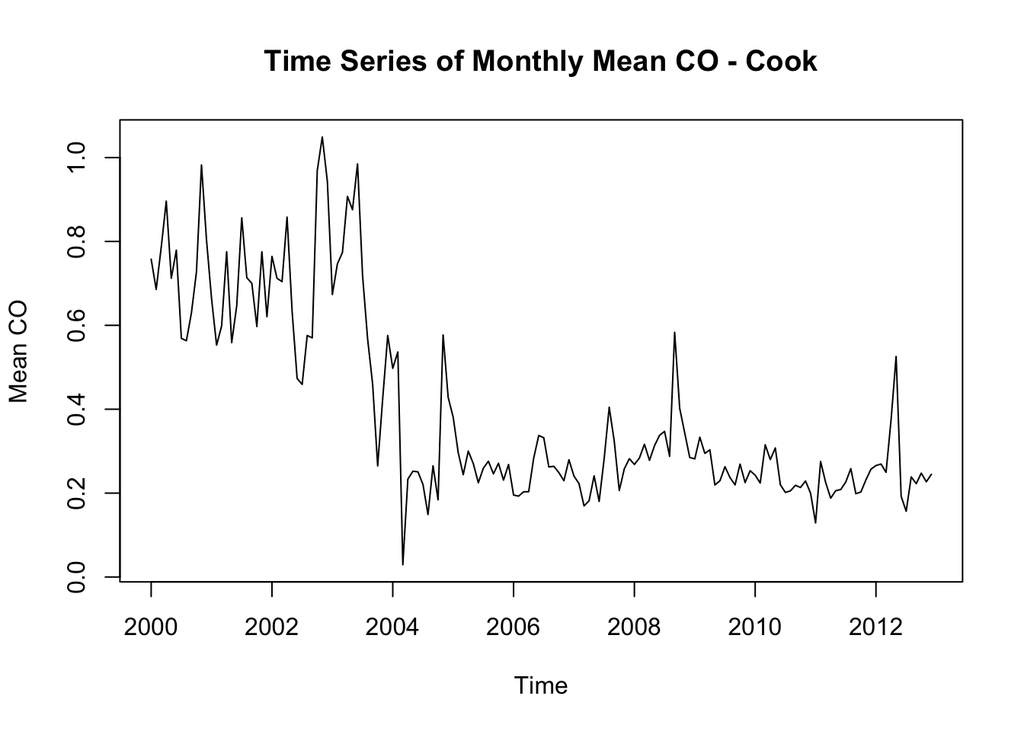

```r
start_year <- year(min(monthly_data$YearMonth))
start_month <- month(min(monthly_data$YearMonth))
ts_CO <- ts(monthly_data$mean_CO, start = c(start_year, start_month), frequency = 12)

# Plot the time series
plot(ts_CO, main = "Time Series of Monthly Mean CO - Cook", ylab = "Mean CO", xlab = "Time")
```

**3. Check for Stationarity using Augmented Dickey-Fuller Test**

```r
# Perform the Augmented Dickey-Fuller Test for stationarity.
adf_test <- adf.test(ts_CO, alternative = "stationary")
print(adf_test)
```

```
##
##  Augmented Dickey-Fuller Test
##
## data:  ts_CO
## Dickey-Fuller = -2.1404, Lag order = 5, p-value = 0.5178
## alternative hypothesis: stationary
```

The data from the output of the Dickey-Fuller Test states that the data we have is not stationary. We will take care of it in the ARIMA model by differencing.

**4. Find out the ACF and PACF**

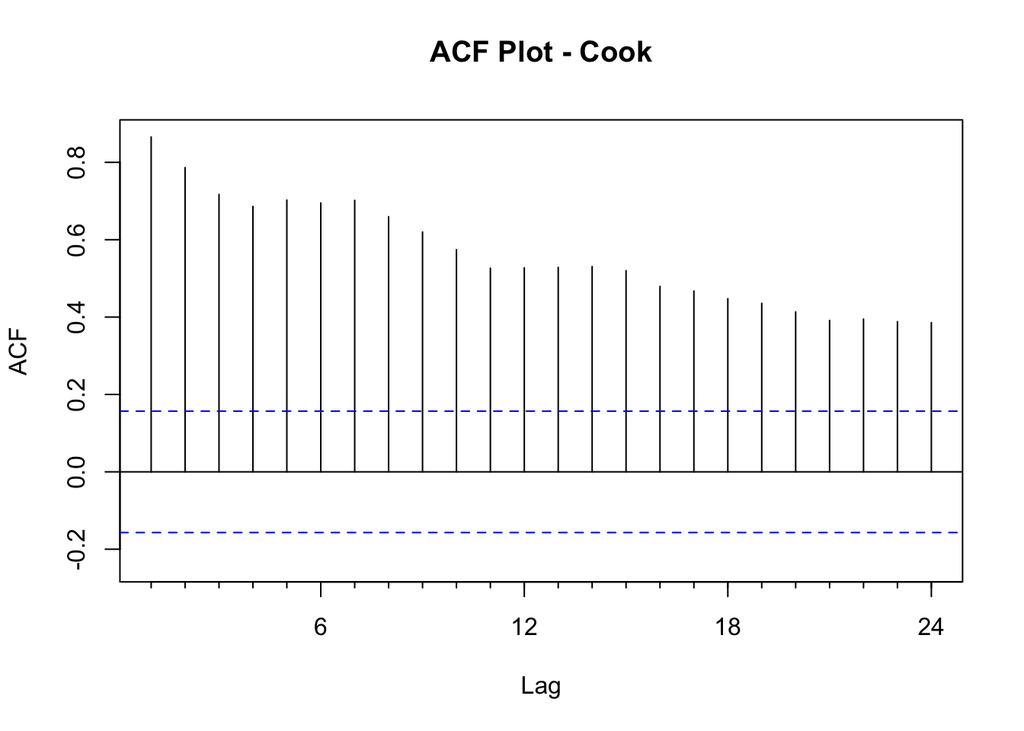

```r
# Plot ACF and PACF for the series
Acf(ts_CO, main = "ACF Plot - Cook")
```

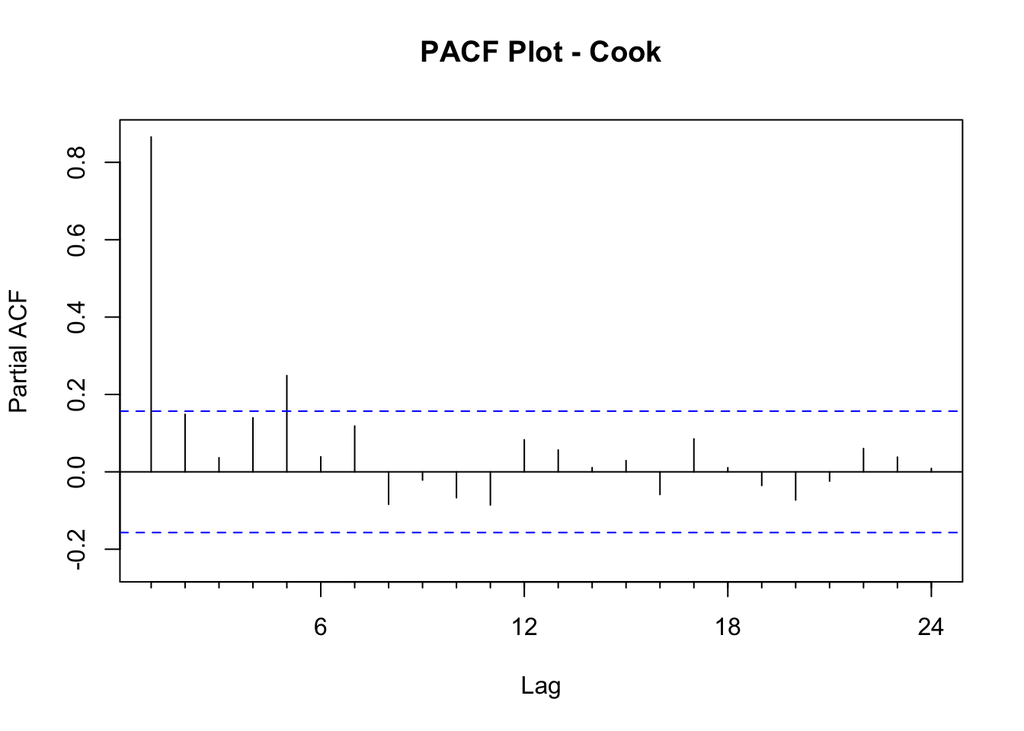

```r
Pacf(ts_CO, main = "PACF Plot - Cook")
```

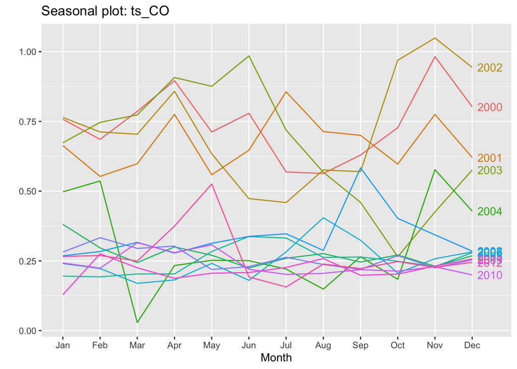

```r
#Plot the seasonal graph for checking the seasonality.
ggseasonplot(ts_CO, year.labels = TRUE)
```

```r
ts_CO_partitioned <- window(ts_CO, start = c(2005, 1))
adf_test <- adf.test(ts_CO_partitioned, alternative = "stationary")
print(adf_test)
```

```
##
##  Augmented Dickey-Fuller Test
##
## data:  ts_CO_partitioned
## Dickey-Fuller = -3.067, Lag order = 4, p-value = 0.1355
## alternative hypothesis: stationary
```

```r
ts_CO_partitioned_diff <- diff(ts_CO_partitioned)
print(adf.test(ts_CO_partitioned_diff, alternative = "stationary"))
```

```
##
##  Augmented Dickey-Fuller Test
##
## data:  ts_CO_partitioned_diff
## Dickey-Fuller = -6.2937, Lag order = 4, p-value = 0.01
## alternative hypothesis: stationary
```

**5. Find out the ACF and PACF after differencing the data.**

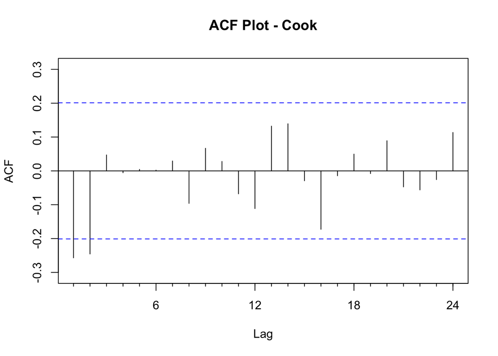

```r
Acf(ts_CO_partitioned_diff, main = "ACF Plot - Cook")
```

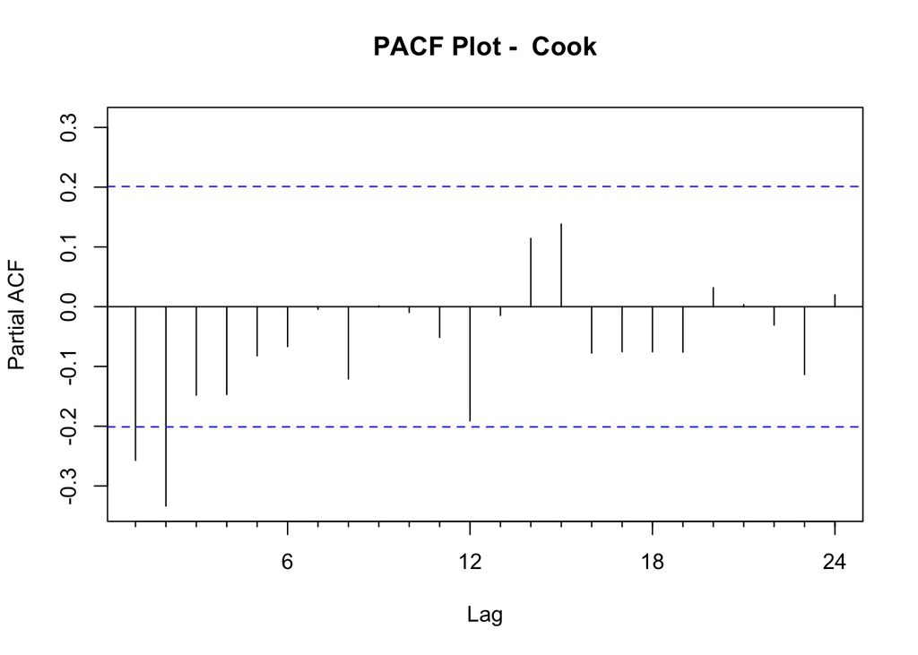

```r
Pacf(ts_CO_partitioned_diff, main = "PACF Plot -  Cook")
```

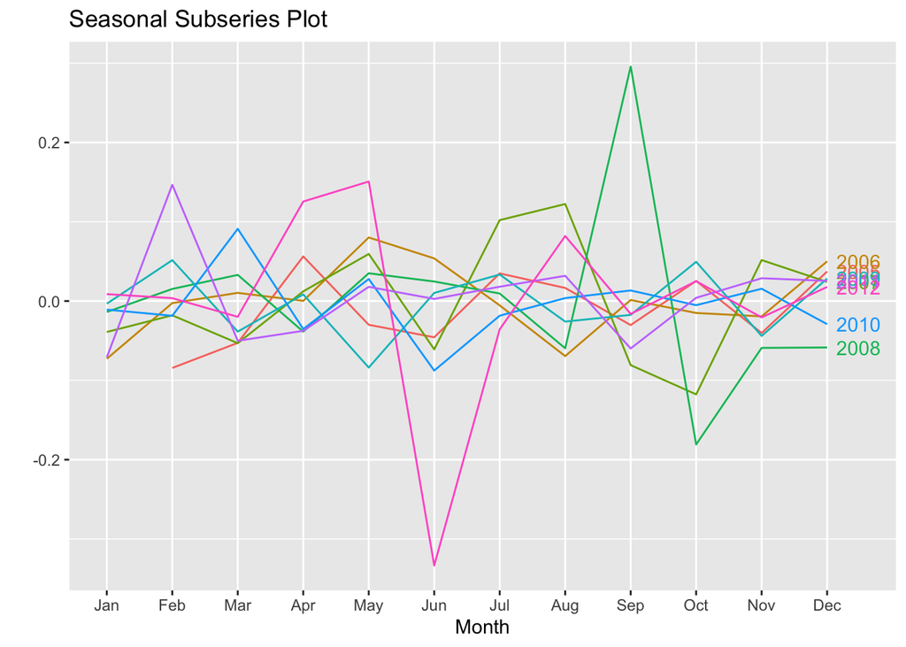

```r
ggseasonplot(ts_CO_partitioned_diff,year.labels = TRUE, main = "Seasonal Subseries Plot")
```

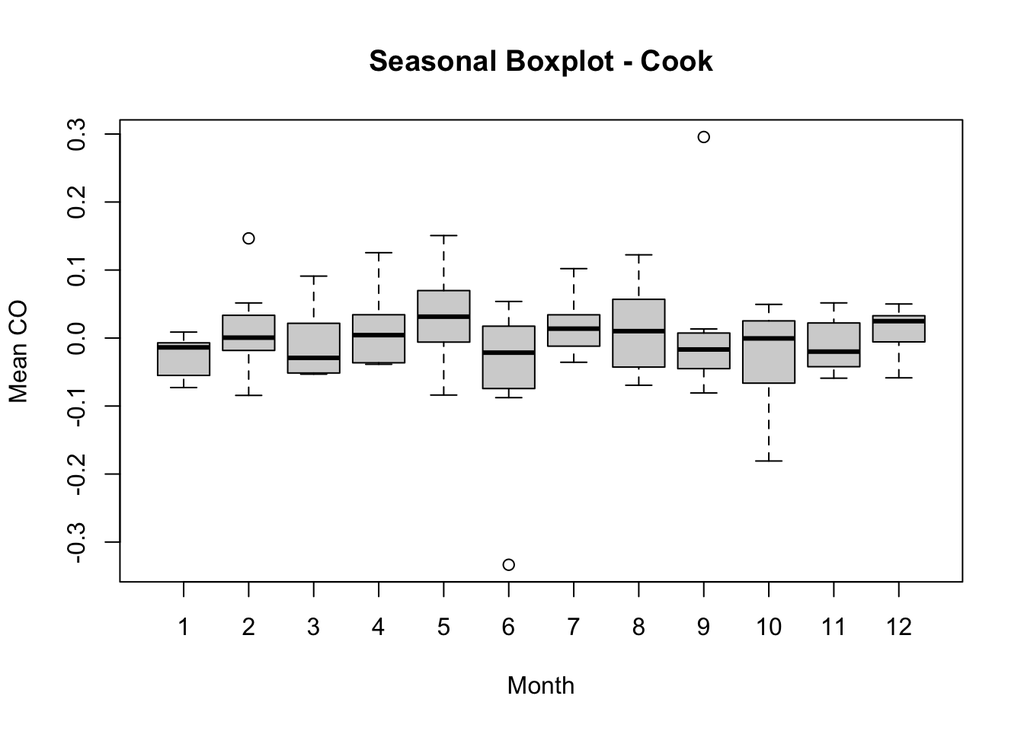

```r
boxplot(ts_CO_partitioned_diff ~ cycle(ts_CO_partitioned_diff), xlab = "Month", ylab = "Mean CO", main = "Seasonal Boxplot - Cook")
```

**6. ARMA Model fitting to the Time Series Data**

```r
auto_model <- auto.arima(ts_CO_partitioned_diff, seasonal = FALSE)
summary(auto_model)
```

```
## Series: ts_CO_partitioned_diff
## ARIMA(0,0,2) with zero mean
##
## Coefficients:
##           ma1      ma2
##       -0.4838  -0.3338
## s.e.   0.1030   0.1156
##
## sigma^2 = 0.00385:  log likelihood = 129.8
## AIC=-253.61   AICc=-253.34   BIC=-245.95
##
## Training set error measures:
##                        ME       RMSE        MAE      MPE     MAPE     MASE
## Training set -0.004162175 0.06139167 0.04214907 -49.0998 291.2068 0.560944
##                     ACF1
## Training set 0.002177341
```

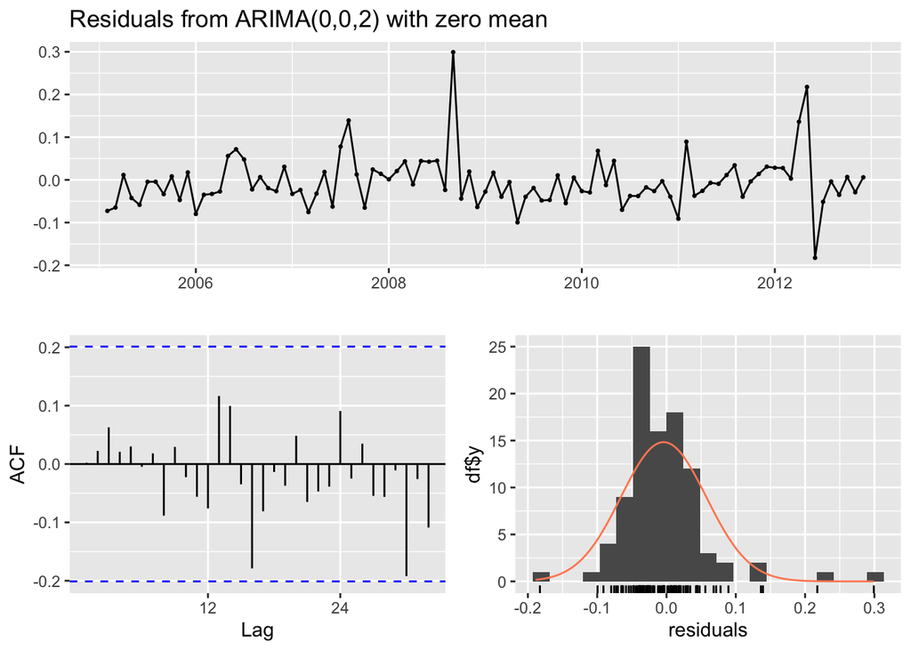

```
##
##  Ljung-Box test
##
## data:  Residuals from ARIMA(0,0,2) with zero mean
## Q* = 10.066, df = 17, p-value = 0.9008
##
## Model df: 2.   Total lags used: 19
```

```r
checkresiduals(auto_model)
```

**7. Forecasting and Model Evaluation for Cook**

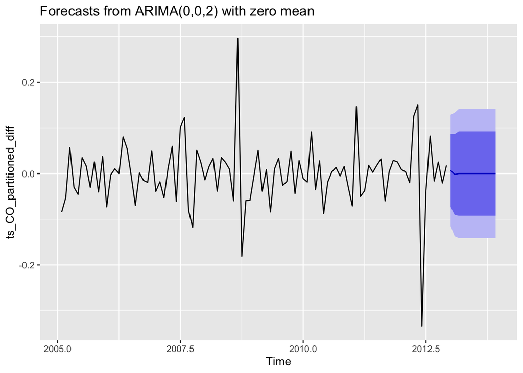

```r
future_forecast <- forecast(auto_model, h = 12)
autoplot(future_forecast)
```

```r
summary(future_forecast)
```

```
##
## Forecast method: ARIMA(0,0,2) with zero mean
##
## Model Information:
## Series: ts_CO_partitioned_diff
## ARIMA(0,0,2) with zero mean
##
## Coefficients:
##           ma1      ma2
##       -0.4838  -0.3338
## s.e.   0.1030   0.1156
##
## sigma^2 = 0.00385:  log likelihood = 129.8
## AIC=-253.61   AICc=-253.34   BIC=-245.95
##
## Error measures:
##                        ME       RMSE        MAE      MPE     MAPE     MASE
## Training set -0.004162175 0.06139167 0.04214907 -49.0998 291.2068 0.560944
##                     ACF1
## Training set 0.002177341
##
## Forecasts:
##          Point Forecast       Lo 80      Hi 80      Lo 95     Hi 95
## Jan 2013    0.006803416 -0.07271465 0.08632149 -0.1148090 0.1284158
## Feb 2013   -0.002005477 -0.09034085 0.08632989 -0.1371028 0.1330918
## Mar 2013    0.000000000 -0.09223604 0.09223604 -0.1410628 0.1410628
## Apr 2013    0.000000000 -0.09223604 0.09223604 -0.1410628 0.1410628
## May 2013    0.000000000 -0.09223604 0.09223604 -0.1410628 0.1410628
## Jun 2013    0.000000000 -0.09223604 0.09223604 -0.1410628 0.1410628
## Jul 2013    0.000000000 -0.09223604 0.09223604 -0.1410628 0.1410628
## Aug 2013    0.000000000 -0.09223604 0.09223604 -0.1410628 0.1410628
## Sep 2013    0.000000000 -0.09223604 0.09223604 -0.1410628 0.1410628
## Oct 2013    0.000000000 -0.09223604 0.09223604 -0.1410628 0.1410628
## Nov 2013    0.000000000 -0.09223604 0.09223604 -0.1410628 0.1410628
## Dec 2013    0.000000000 -0.09223604 0.09223604 -0.1410628 0.1410628
```

**Part IV: Time Series ~ Maricopa**

```r
cleaned_df_maricopa <- subset(cleaned_df, County == "Maricopa")

cleaned_df_maricopa_floored <- cleaned_df_maricopa %>%
  mutate(YearMonth = floor_date(Date.Local, "month"))
```

```r
monthly_data_maricopa <- cleaned_df_maricopa_floored %>%
  group_by(YearMonth) %>%
  summarise(mean_CO = mean(CO.Mean, na.rm = TRUE))
```

**1. Plot the Time Series for Maricopa**

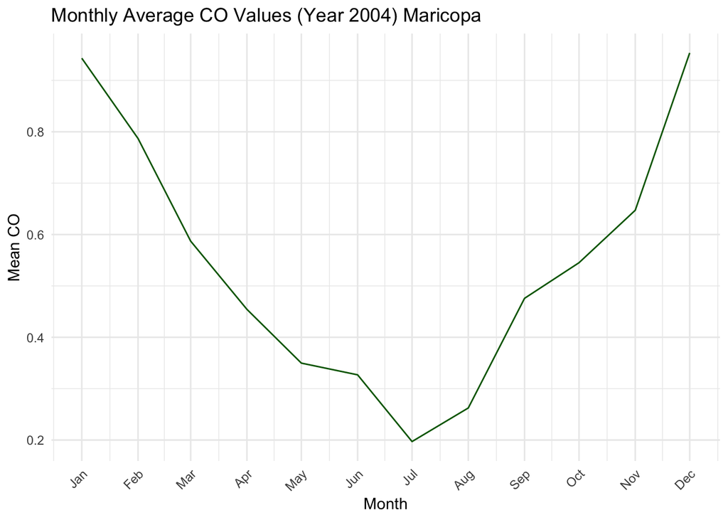

```r
monthly_data_maricopa$YearMonth <- as.Date(monthly_data_maricopa$YearMonth)

monthly_data_maricopa_2004 <- monthly_data_maricopa %>%
  filter(format(YearMonth, "%Y") == "2004")

ggplot(monthly_data_maricopa_2004, aes(x = YearMonth, y = mean_CO)) +
  geom_line(color = "darkgreen") +
  labs(title = "Monthly Average CO Values (Year 2004) Maricopa",
       x = "Month",
       y = "Mean CO") +
  scale_x_date(date_breaks = "1 month", date_labels = "%b") +  # Show each month name
  theme_minimal() +
  theme(axis.text.x = element_text(angle = 45, hjust = 1))
```

**2. Plot the Monthly Mean Time Series for Maricopa**

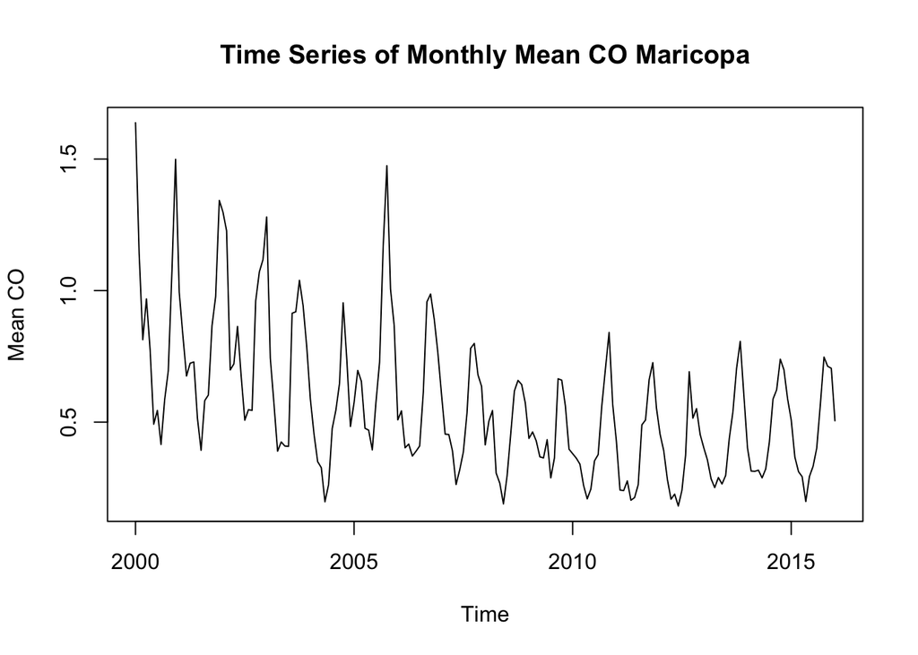

```r
start_year_mc <- year(min(monthly_data_maricopa$YearMonth))
start_month_mc <- month(min(monthly_data_maricopa$YearMonth))
ts_CO_mc <- ts(monthly_data_maricopa$mean_CO, start = c(start_year_mc, start_month_mc), frequency = 12)

# Plot the time series
plot(ts_CO_mc, main = "Time Series of Monthly Mean CO Maricopa", ylab = "Mean CO", xlab = "Time")
```

**3. Check for Stationarity using Augmented Dickey-Fuller Test**

```r
# Perform the Augmented Dickey-Fuller Test for stationarity.

adf_test_mc <- adf.test(ts_CO_mc, alternative = "stationary")
print(adf_test_mc)
```

```
##
##  Augmented Dickey-Fuller Test
##
## data:  ts_CO_mc
## Dickey-Fuller = -7.9134, Lag order = 5, p-value = 0.01
## alternative hypothesis: stationary
```

Since the data is already stationary according to the p-value which is 0.01, hence plotting now ACF and PACF

**4. Find out the ACF and PACF for Maricopa**

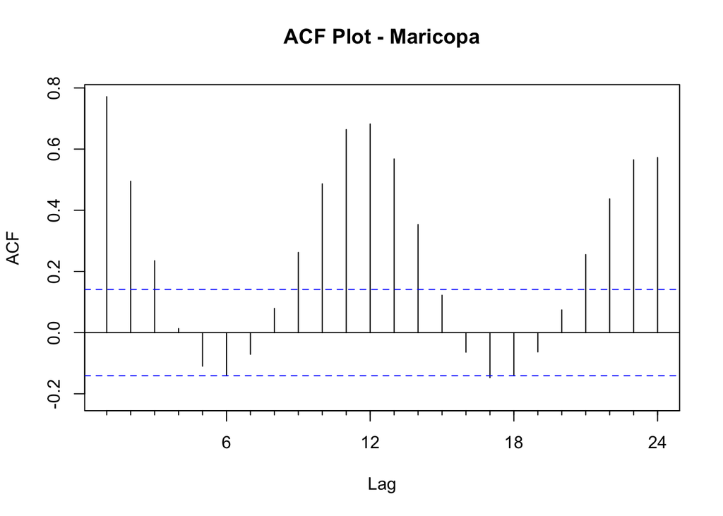

```r
# Plot ACF and PACF for the series

Acf(ts_CO_mc, main = "ACF Plot - Maricopa")
```

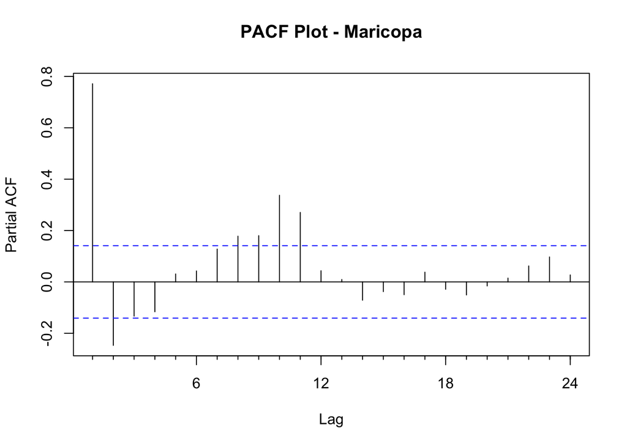

```r
Pacf(ts_CO_mc, main = "PACF Plot - Maricopa")
```

**5. Checking for Seasonality of Time Series Data for Maricopa**

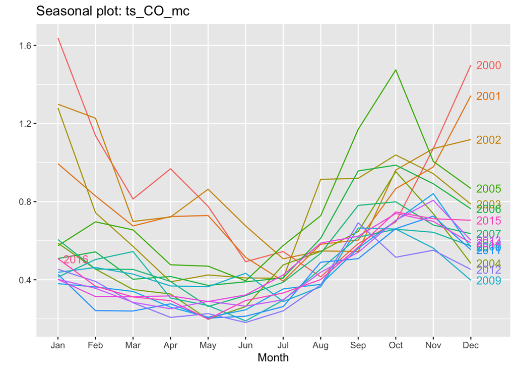

```r
ggseasonplot(ts_CO_mc, year.labels = TRUE)
```

Since the data is stationary and the data is seasonal we are using SARIMA model.

**6. SARIMA Model fitting to the Time Series Data for Maricopa**

```r
auto_model_mc <- auto.arima(ts_CO_mc, seasonal = TRUE)
summary(auto_model_mc)
```

```
## Series: ts_CO_mc
## ARIMA(2,0,1)(2,1,0)[12] with drift
##
## Coefficients:
##           ar1     ar2     ma1     sar1     sar2    drift
##       -0.3152  0.5053  0.9580  -0.4555  -0.1974  -0.0025
## s.e.   0.0840  0.0784  0.0425   0.0798   0.0798   0.0012
##
## sigma^2 = 0.01808:  log likelihood = 107.45
## AIC=-200.9   AICc=-200.25   BIC=-178.51
##
## Training set error measures:
##                        ME      RMSE        MAE       MPE     MAPE      MASE
## Training set 0.0003656805 0.1280348 0.09094913 -1.540108 17.18856 0.6880288
##                    ACF1
## Training set -0.0183167
```

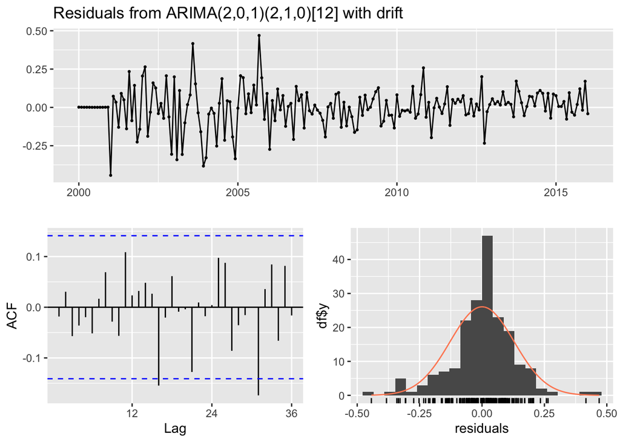

```
##
##  Ljung-Box test
##
## data:  Residuals from ARIMA(2,0,1)(2,1,0)[12] with drift
## Q* = 16.68, df = 19, p-value = 0.6115
##
## Model df: 5.   Total lags used: 24
```

```r
checkresiduals(auto_model_mc)
```

**7. Forecasting and Model Evaluation for Maricopa**

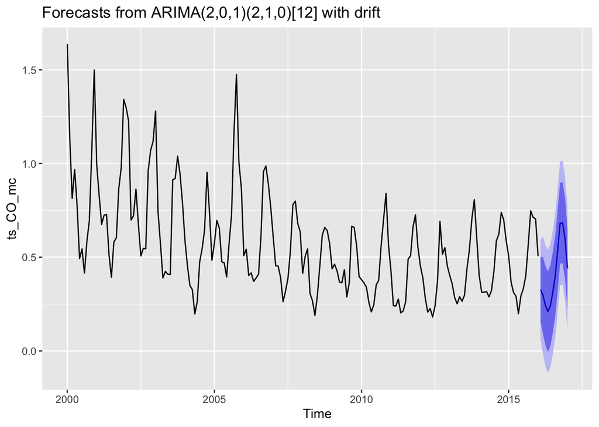

```r
future_forecast_mc <- forecast(auto_model_mc, h = 12)
autoplot(future_forecast_mc)
```

```r
summary(future_forecast_mc)
```

```
##
## Forecast method: ARIMA(2,0,1)(2,1,0)[12] with drift
##
## Model Information:
## Series: ts_CO_mc
## ARIMA(2,0,1)(2,1,0)[12] with drift
##
## Coefficients:
##           ar1     ar2     ma1     sar1     sar2    drift
##       -0.3152  0.5053  0.9580  -0.4555  -0.1974  -0.0025
## s.e.   0.0840  0.0784  0.0425   0.0798   0.0798   0.0012
##
## sigma^2 = 0.01808:  log likelihood = 107.45
## AIC=-200.9   AICc=-200.25   BIC=-178.51
##
## Error measures:
##                        ME      RMSE        MAE       MPE     MAPE      MASE
## Training set 0.0003656805 0.1280348 0.09094913 -1.540108 17.18856 0.6880288
##                    ACF1
## Training set -0.0183167
##
## Forecasts:
##          Point Forecast        Lo 80     Hi 80       Lo 95     Hi 95
## Feb 2016      0.3274836  0.155168345 0.4997988  0.06395018 0.5910169
## Mar 2016      0.2969797  0.092141332 0.5018180 -0.01629354 0.6102529
## Apr 2016      0.2418269  0.030453361 0.4532005 -0.08144105 0.5650949
## May 2016      0.2100211 -0.005015305 0.4250574 -0.11884868 0.5388908
## Jun 2016      0.2397045  0.024219694 0.4551892 -0.08985105 0.5692600
## Jul 2016      0.3114538  0.095405906 0.5275017 -0.01896294 0.6418705
## Aug 2016      0.4003381  0.184279934 0.6163963  0.06990565 0.7307705
## Sep 2016      0.5350588  0.318880307 0.7512373  0.20444231 0.8656753
## Oct 2016      0.6812858  0.465103929 0.8974677  0.35066414 1.0119075
## Nov 2016      0.6841855  0.467966125 0.9004049  0.35350650 1.0148645
## Dec 2016      0.5999950  0.383767453 0.8162226  0.26930350 0.9306865
## Jan 2017      0.4406459  0.224402360 0.6568894  0.10992996 0.7713618
```

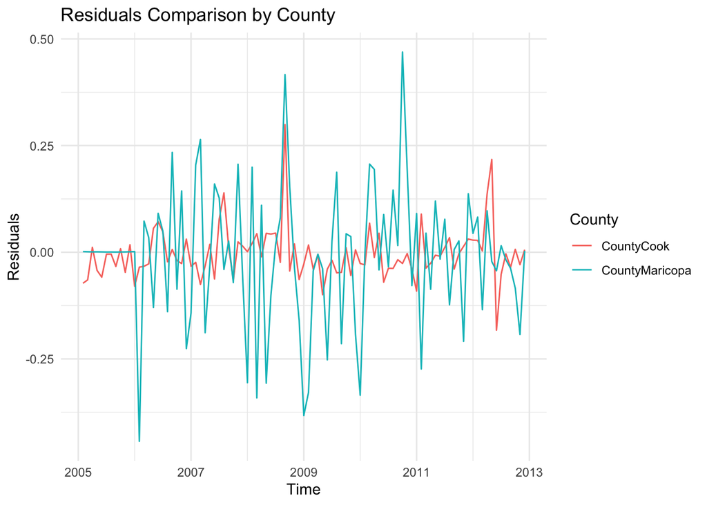

```r
resid1 <- residuals(auto_model)
resid2 <- residuals(auto_model_mc)

min_len <- min(length(resid1), length(resid2))

# Trim both residuals to that length
resid1_trim <- resid1[1:min_len]
resid2_trim <- resid2[1:min_len]
time_vals <- time(resid1)[1:min_len]  # assuming both have same time index structure

# Now create the tibble
df_resid <- tibble::tibble(
  Time = time_vals,
  CountyCook = as.numeric(resid1_trim),
  CountyMaricopa = as.numeric(resid2_trim)
)

# Reshape for plotting
df_long <- tidyr::pivot_longer(df_resid, cols = c(CountyCook, CountyMaricopa),
                                names_to = "County", values_to = "Residual")

# Plot
library(ggplot2)
ggplot(df_long, aes(x = Time, y = Residual, color = County)) +
  geom_line() +
  labs(title = "Residuals Comparison by County",
       x = "Time", y = "Residuals") +
  theme_minimal()
```

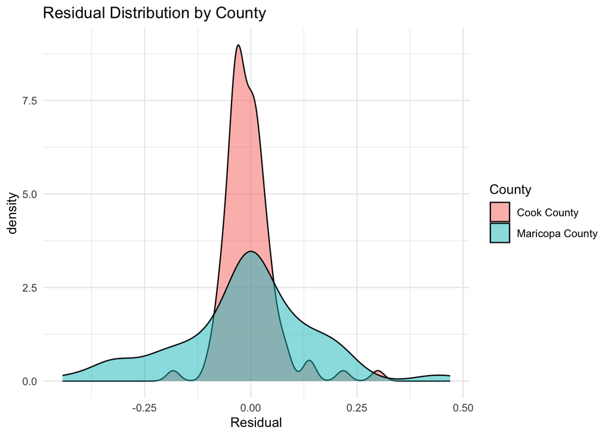

```r
df_density <- data.frame(
  Residual = c(resid1_trim, resid2_trim),
  County = rep(c("Cook County", "Maricopa County"), each = length(resid1_trim))
)

ggplot(df_density, aes(x = Residual, fill = County)) +
  geom_density(alpha = 0.5) +
  labs(title = "Residual Distribution by County") +
  theme_minimal()
```